# Project 2

Simon Kauppinen

# Chapter 7.9 Problem 9

```r
library("latex2exp")
library("ISLR2")
library("boot")
library("glue")
library("tinytex")
library("polynom")
library("MASS")
library("splines")
```

a)

```r
#Uses a degree d polynomial to predict nox with dis.
poly.fit <- function(d){
  lm(nox~poly(dis,d), data=Boston)
}

# A set of points along values of dis to be used later for graphing the image of fitted polynomials.
x <- with(Boston, seq(min(dis), max(dis), length.out=400))


#Plots the fitted polynomial with degree d together with the associated RSS.
poly.plot <- function(d){
  pred <- predict(poly.fit(d),newdata=data.frame(dis=x),se.fit=TRUE)
  rss <- round(sum(poly.fit(d)$residuals^2),4)
  plot(nox~dis,data=Boston, main=TeX(sprintf(r'(Degree $%d$ fit with $\pm$ 2 SE)',d)),xlab='Dis',ylab='Nox',col='grey')
  lines(x, pred$fit, lwd=2)
  lines(x, pred$fit + 2*pred$se.fit, lty="dashed")
  lines(x, pred$fit - 2*pred$se.fit, lty="dashed")
  legend("topright",legend=glue('RSS=',rss))
}

#Plots summary of the fitted cubic polynomial
summary(poly.fit(3))
```

```
##
## Call:
## lm(formula = nox ~ poly(dis, d), data = Boston)
##
## Residuals:
##       Min        1Q    Median        3Q       Max
## -0.121130 -0.040619 -0.009738  0.023385  0.194904
##
## Coefficients:
##                Estimate Std. Error t value Pr(>|t|)
## (Intercept)    0.554695   0.002759 201.021  < 2e-16 ***
## poly(dis, d)1 -2.003096   0.062071 -32.271  < 2e-16 ***
## poly(dis, d)2  0.856330   0.062071  13.796  < 2e-16 ***
## poly(dis, d)3 -0.318049   0.062071  -5.124 4.27e-07 ***
## ---
## Signif. codes:  0 '***' 0.001 '**' 0.01 '*' 0.05 '.' 0.1 ' ' 1
##
## Residual standard error: 0.06207 on 502 degrees of freedom
## Multiple R-squared:  0.7148, Adjusted R-squared:  0.7131
## F-statistic: 419.3 on 3 and 502 DF,  p-value: < 2.2e-16
```

In the summary we can see that the p-value for the polynomial regression and each coefficient is very small (p<0.0001). The coefficients of the cubic polynomial are

0.5547, -2.0031, 0.8563, -0.318

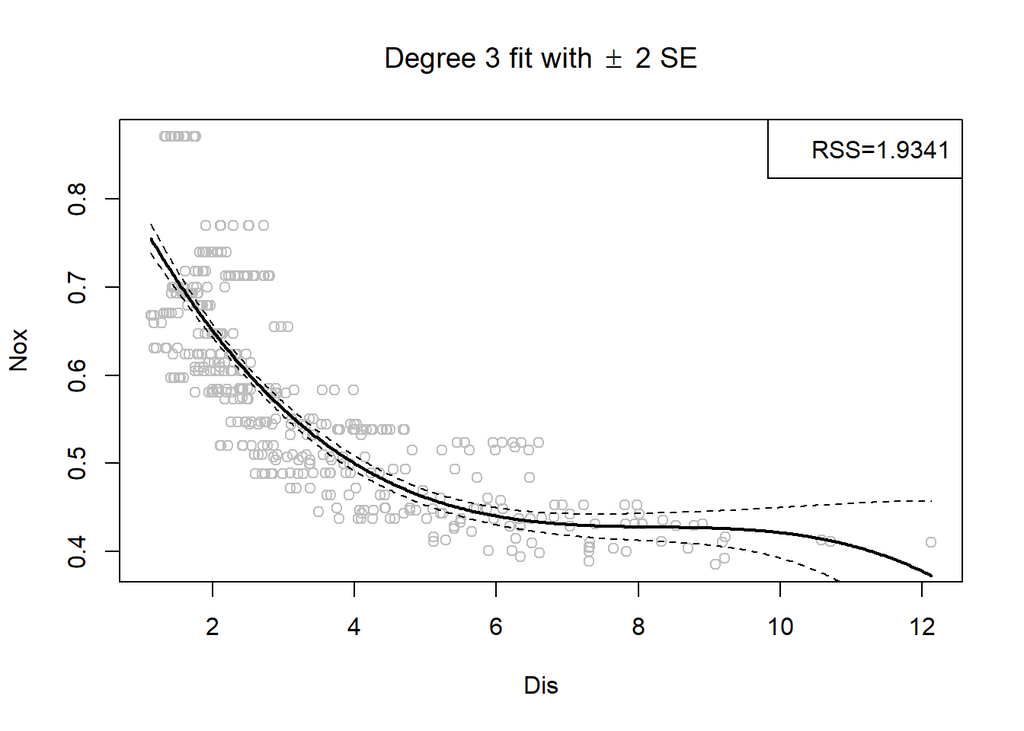

```r
poly.plot(3)
```

b)

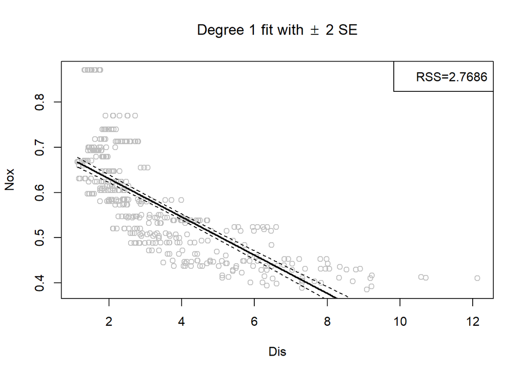

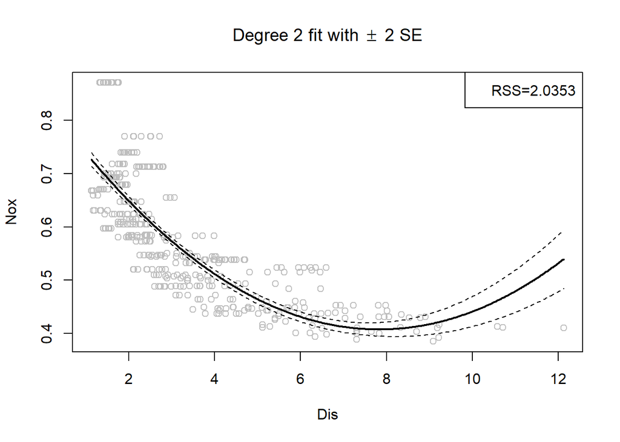

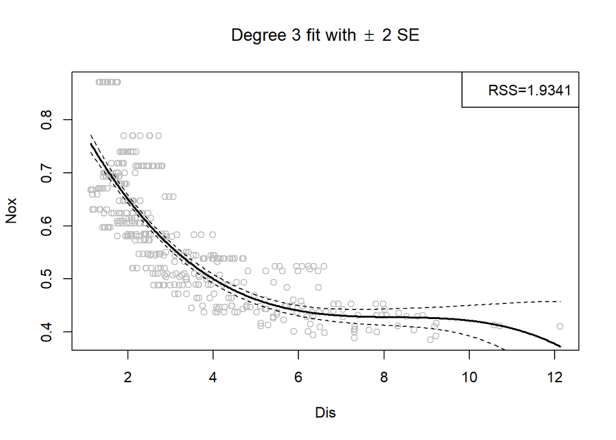

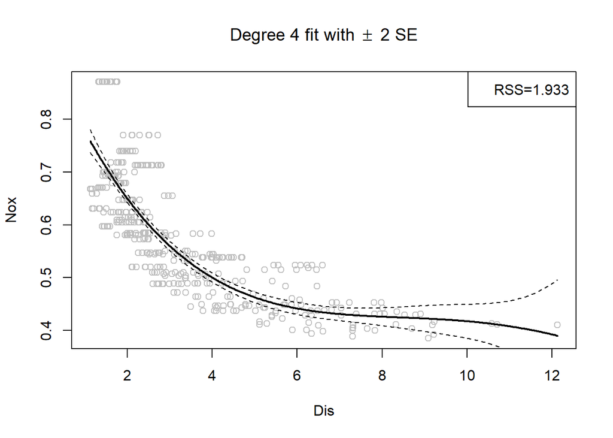

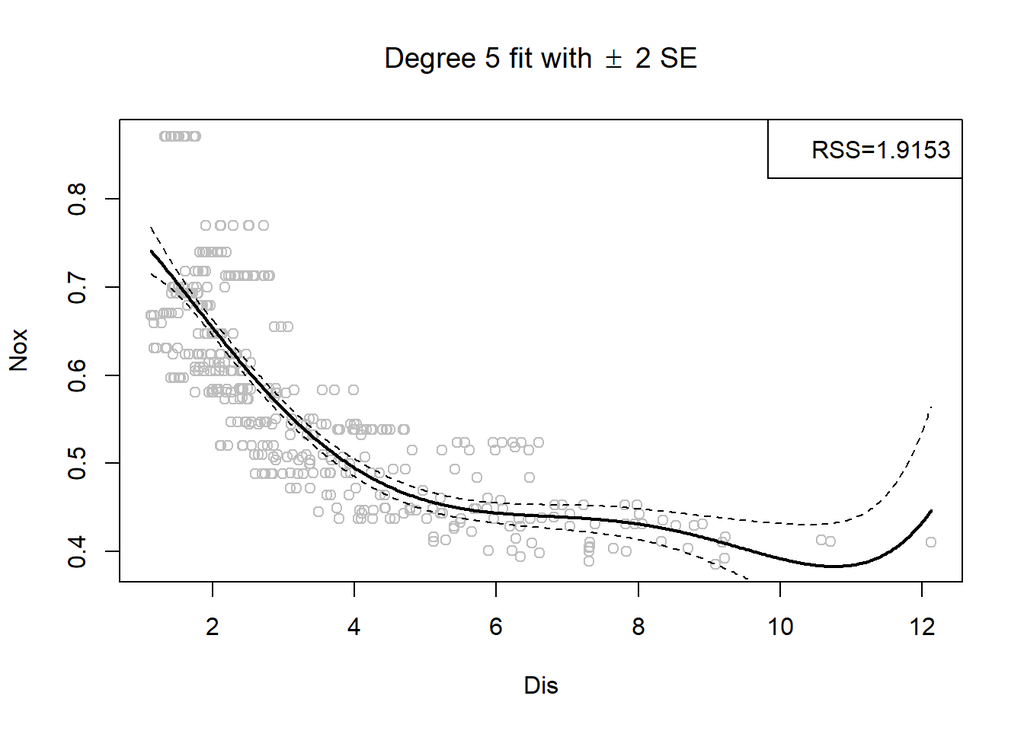

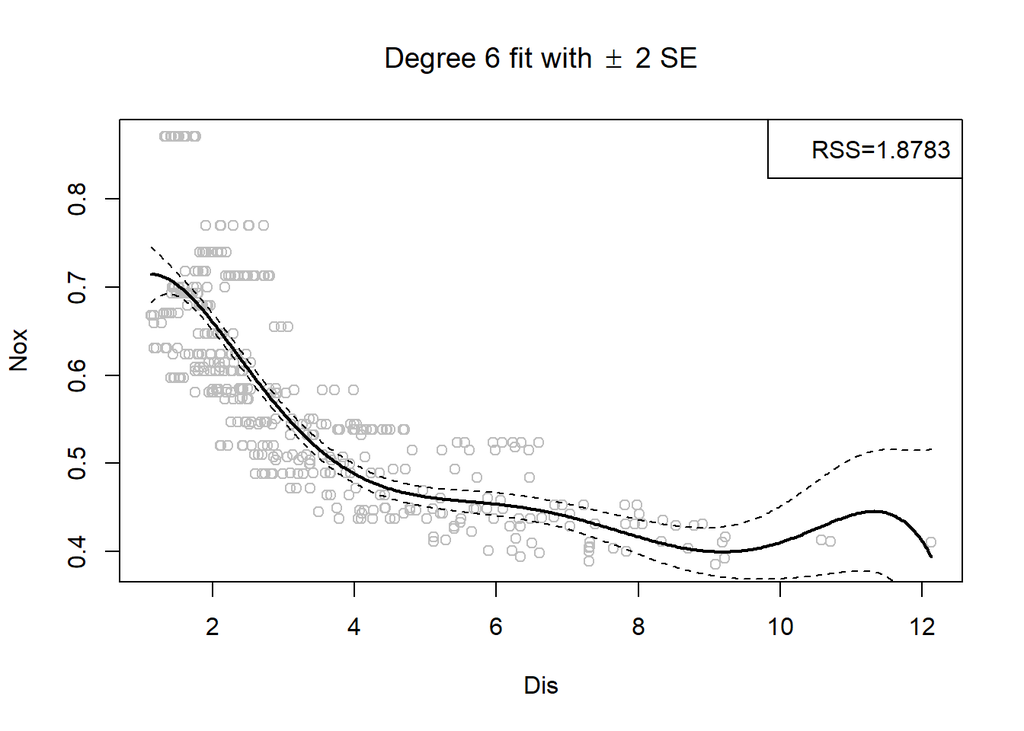

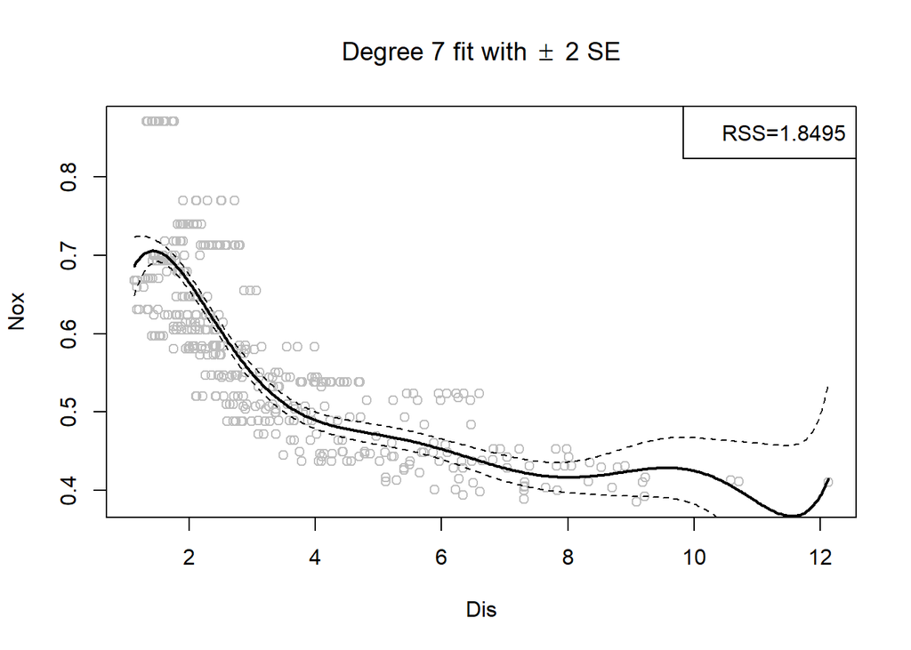

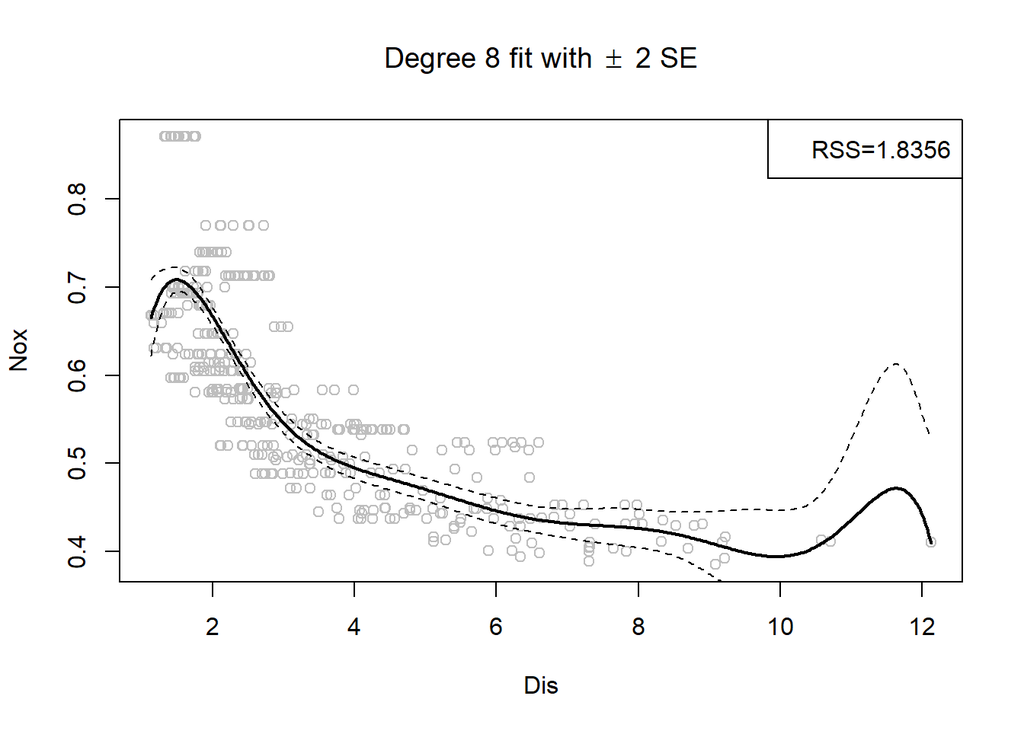

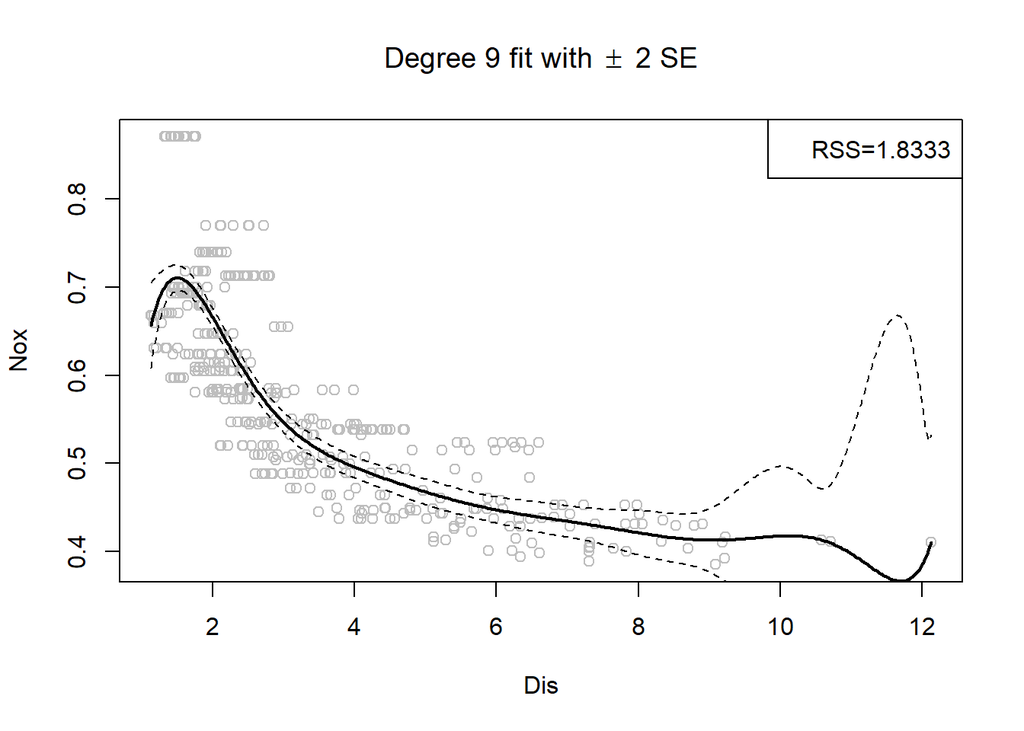

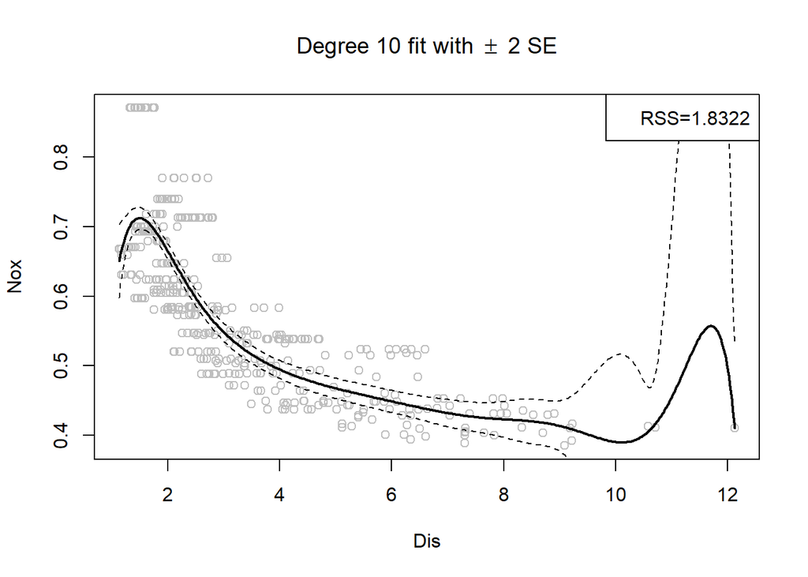

```r
#Plots the fitted polynomial for degrees 1-10 with their associated RSS
invisible(sapply(1:10,poly.plot))
```

c)

```r
set.seed(1)

get_optimal_d <- function(){

  #While loop to determine the highest degree such that all predictors are significant.
  max_degree <- 1
  while(TRUE){
    if(all(summary(poly.fit(max_degree))$coefficients[,4] < 0.05)==TRUE){
      max_degree <- max_degree +1
    } else {
      max_degree <- max_degree -1
      break}
  }

  # Performs 10-fold cross-validation for each polynomial up to the max degree and collects their associated RSS.
  cv.error <- sapply(1:max_degree,function(d){
  fit <- glm(nox~poly(dis,d),data=Boston)
  cv.glm(Boston,fit,K=10)$delta[1]
  })

  #Returns the degree with the smallest CV error.
  return(which.min(cv.error))
}

get_optimal_d()
```

```
## [1] 3
```

Based on cross-validation on the polynomials with only significant predictors, the degree of the polynomial with the smallest CV error is 3

d)

```r
#Knots are placed at equally-spaced quantiles of dis by the 'df' argument in bs.
spline.fit <- function(df){
  return(lm(nox~bs(dis,df=df), data=Boston))
}

#Function for plotting the regression spline with df degrees of freedom
spline.plot <- function(df){
  spline.pred <- predict(spline.fit(df),newdata=data.frame(dis=x),se.fit=TRUE)
  rss <- round(sum(summary(spline.fit(df))$residuals^2),4)
  plot(Boston$dis,Boston$nox,xlab='Dis',ylab='Nox',col='grey',
       main=paste('Regression spline with', df, 'df','\n Dashed lines +- 2 SE'))
  lines(x,spline.pred$fit,lwd=2)
  lines(x,spline.pred$fit + 2 *spline.pred$se.fit, lty="dashed")
  lines(x,spline.pred$fit - 2 *spline.pred$se.fit, lty="dashed")
  legend("topright", legend=glue('RSS=', rss))
}

print(summary(spline.fit(4)))
```

```
##
## Call:
## lm(formula = nox ~ bs(dis, df = df), data = Boston)
##
## Residuals:
##       Min        1Q    Median        3Q       Max
## -0.124622 -0.039259 -0.008514  0.020850  0.193891
##
## Coefficients:
##                   Estimate Std. Error t value Pr(>|t|)
## (Intercept)        0.73447    0.01460  50.306  < 2e-16 ***
## bs(dis, df = df)1 -0.05810    0.02186  -2.658  0.00812 **
## bs(dis, df = df)2 -0.46356    0.02366 -19.596  < 2e-16 ***
## bs(dis, df = df)3 -0.19979    0.04311  -4.634 4.58e-06 ***
## bs(dis, df = df)4 -0.38881    0.04551  -8.544  < 2e-16 ***
## ---
## Signif. codes:  0 '***' 0.001 '**' 0.01 '*' 0.05 '.' 0.1 ' ' 1
##
## Residual standard error: 0.06195 on 501 degrees of freedom
## Multiple R-squared:  0.7164, Adjusted R-squared:  0.7142
## F-statistic: 316.5 on 4 and 501 DF,  p-value: < 2.2e-16
```

Summary shows that the regression spline with four degrees of freedom has Adjusted R^2 0.7142, p < 2.2e^-16. The coefficients 0.7345, -0.0581, -0.4636, -0.1998, -0.3888 are all significant.

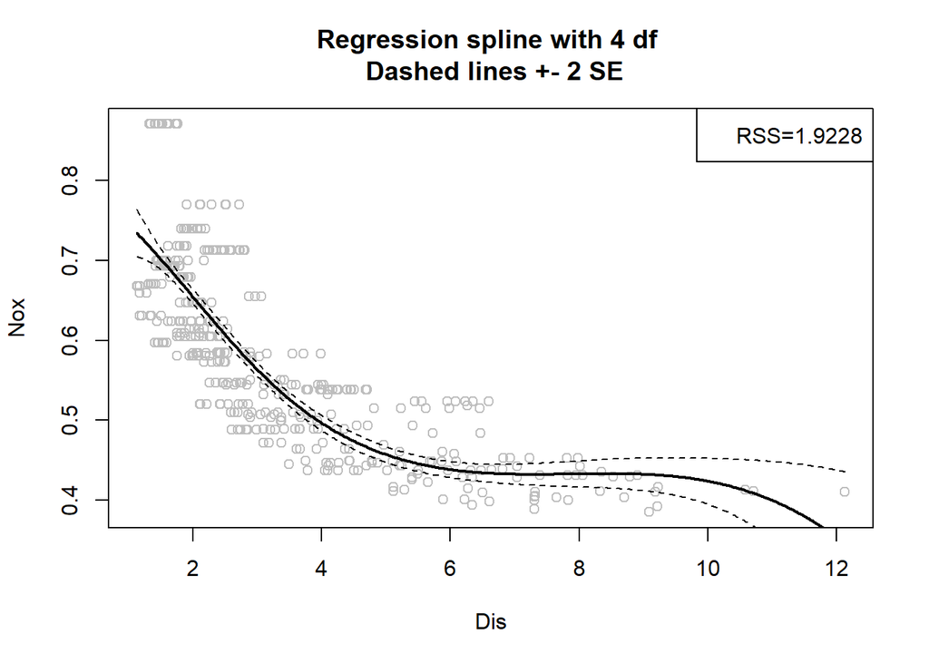

```r
spline.plot(4)
```

e)

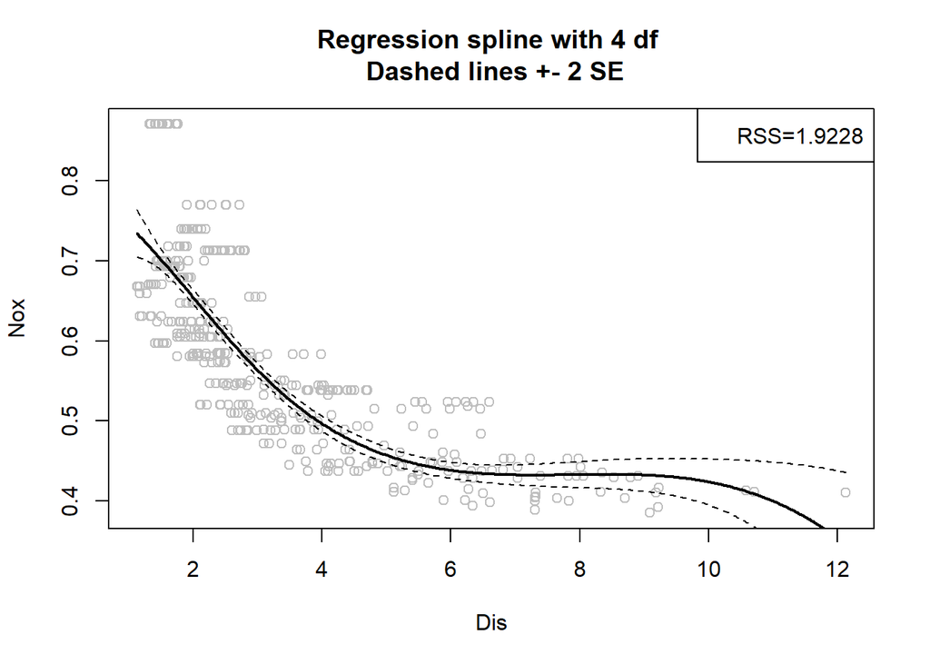

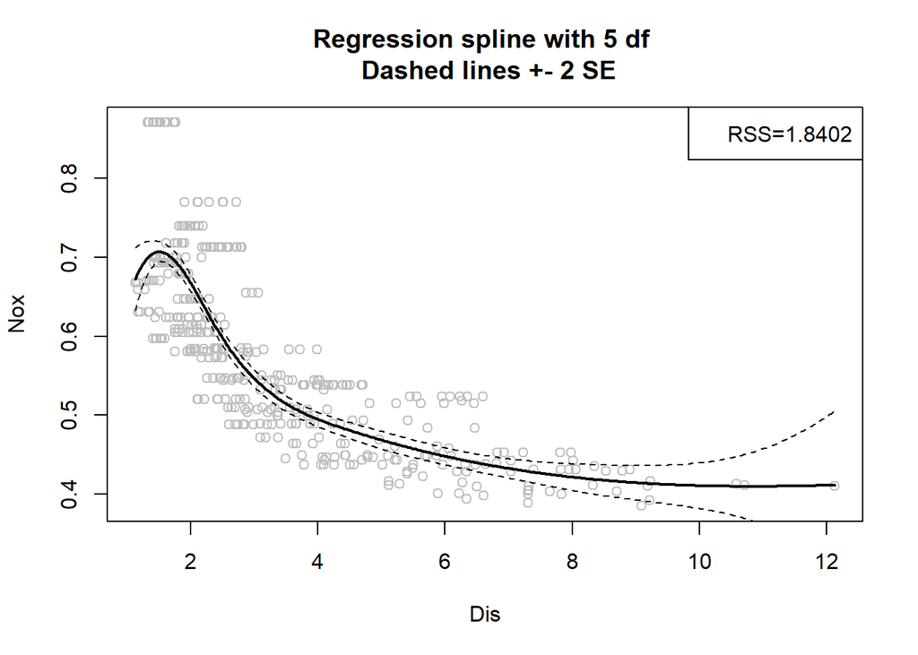

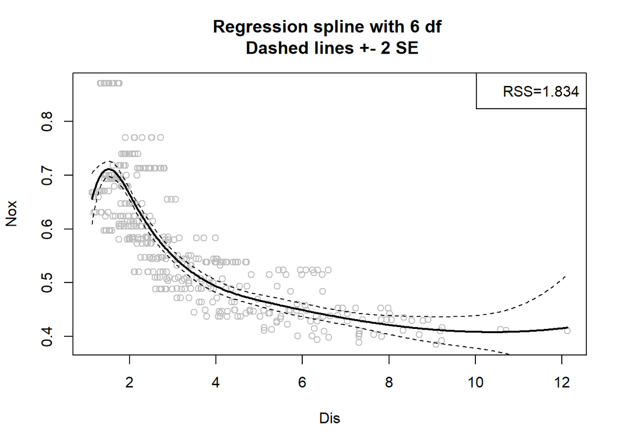

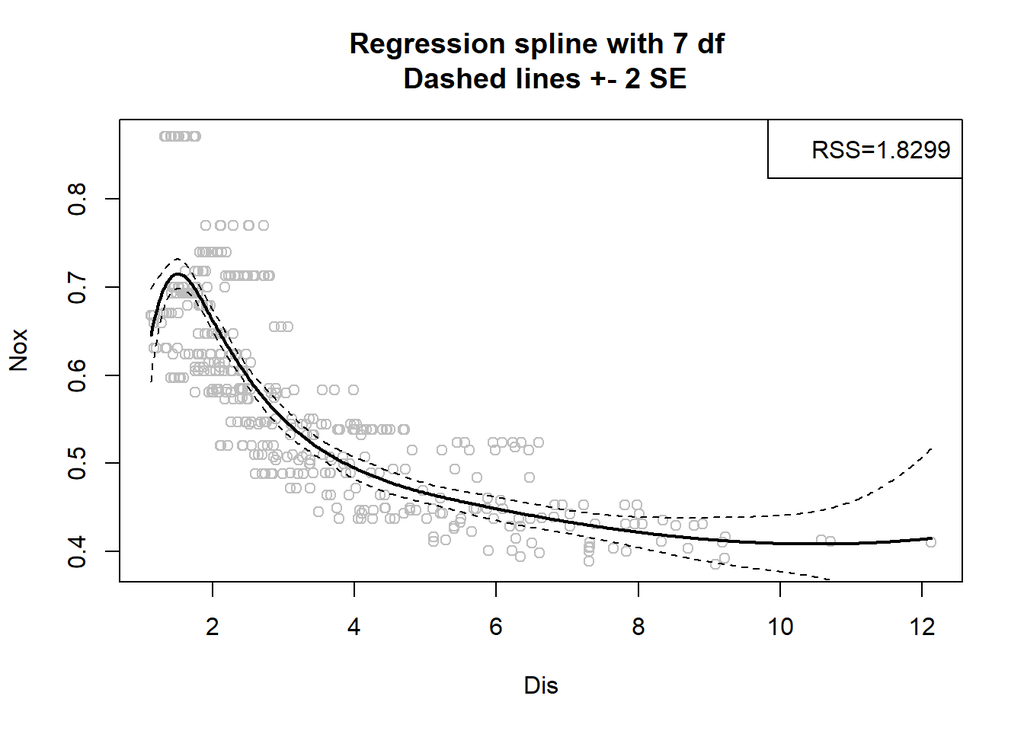

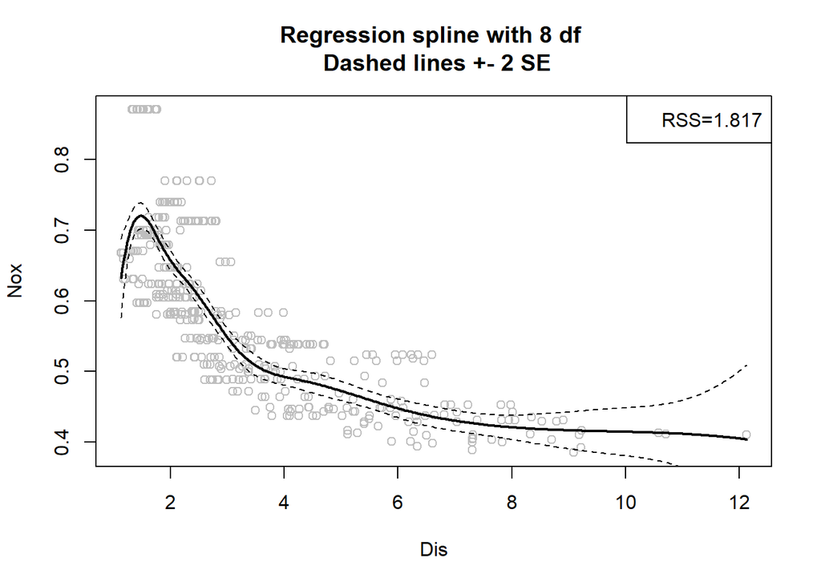

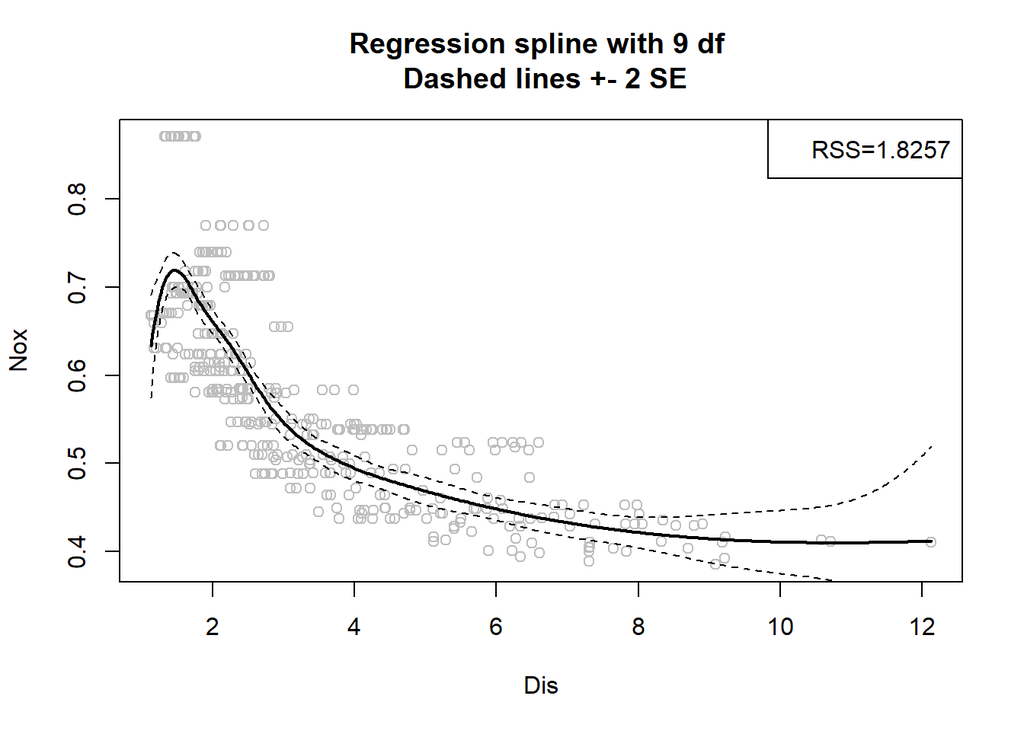

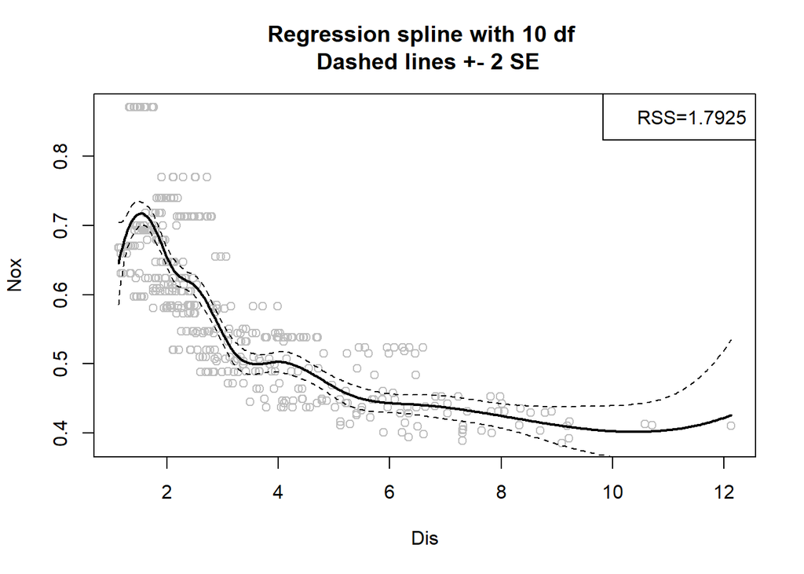

```r
invisible(sapply(4:10,spline.plot))
```

From the plots we see that the RSS usually decreases as the df increases, however the polynomials also seem increasingly overfitted.

```r
set.seed(1)

get_optimal_df <- function(){

  #While loop to determine the largest degrees of freedom such that all predictors are significant.
  max_df <- 4
  while(TRUE){
    if(all(summary(spline.fit(max_df))$coefficients[,4] < 0.05)==TRUE){
      max_df <- max_df +1
    } else {
      max_df <- max_df -1
      break}
  }

  # Performs 10-fold cross-validation for each regression spline up to the max degrees of freedom and collects their associated RSS.
  cv.error <- sapply(4:max_df,function(d){
  fit <- glm(nox~bs(dis,df=d),data=Boston)
  cv.glm(Boston,fit,K=10)$delta[1]
  })

  #Returns the number of degrees of freedom associated with the smallest CV error.
  return(which.min(cv.error)+3)
}

print(get_optimal_df())
```

```
## [1] 5
```

```r
print(summary(spline.fit(get_optimal_df())))
```

```
##
## Call:
## lm(formula = nox ~ bs(dis, df = df), data = Boston)
##
## Residuals:
##       Min        1Q    Median        3Q       Max
## -0.132814 -0.039097 -0.008521  0.023493  0.197761
##
## Coefficients:
##                   Estimate Std. Error t value Pr(>|t|)
## (Intercept)        0.67248    0.01996  33.699  < 2e-16 ***
## bs(dis, df = df)1  0.08311    0.02875   2.891  0.00401 **
## bs(dis, df = df)2 -0.13460    0.01985  -6.782 3.35e-11 ***
## bs(dis, df = df)3 -0.25505    0.03477  -7.336 8.95e-13 ***
## bs(dis, df = df)4 -0.26785    0.04059  -6.599 1.06e-10 ***
## bs(dis, df = df)5 -0.26103    0.05214  -5.007 7.69e-07 ***
## ---
## Signif. codes:  0 '***' 0.001 '**' 0.01 '*' 0.05 '.' 0.1 ' ' 1
##
## Residual standard error: 0.06067 on 500 degrees of freedom
## Multiple R-squared:  0.7286, Adjusted R-squared:  0.7259
## F-statistic: 268.5 on 5 and 500 DF,  p-value: < 2.2e-16
```

# Chapter 8 Problem 11

a)

```r
library("ISLR2")
library("gbm")

data <- Caravan
data$Purchase <- as.integer(data$Purchase == "Yes") #Transforms Purchase values from no and yes to 0 and 1
training_data <- data[1:1000,]
test_data <- data[-(1:1000),]
```

b)

```r
set.seed(1)
boost.caravan <- gbm(Purchase ~ . , data = training_data, n.trees=1000,
                     interaction.depth = 2, shrinkage = 0.01, distribution = "bernoulli")
#Fits a boosting model to the training pdata with 1000 trees, 0.01 shrinkage and 2 split per tree.

head(summary(boost.caravan, plotit=FALSE)) # Prints the six most important predictors
```

```
##               var  rel.inf
## PPERSAUT PPERSAUT 9.881968
## MKOOPKLA MKOOPKLA 7.090575
## MOPLHOOG MOPLHOOG 5.973837
## PBRAND     PBRAND 5.427953
## MGODGE     MGODGE 5.375333
## MBERMIDD MBERMIDD 3.948474
```

The most important predictors seem to be PPERSAUT, MKOOPKLA, MOPLHOOG, PBRAND, MGODGE, MBERMIDD

c)

```r
yhat.boost <- predict(boost.caravan, newdata=test_data, n.trees=1000, type="response")

yhat.boost <- ifelse(yhat.boost > 0.2, 1, 0)

confusionmatrix <- table(predicted=yhat.boost, true=test_data$Purchase)

print(confusionmatrix)
```

```
##          true
## predicted    0    1
##         0 4359  252
##         1  174   37
```

The fraction of people predicted to make a purchase by the boosted tree that in fact made one is $\frac{37}{174+ 37} = 0.1754$

```r
lr.fit <- glm(Purchase ~ ., data=training_data, family='binomial')
lr.probs <- predict(lr.fit, test_data, type="response")
lr.pred <- ifelse(lr.probs > 0.5, 1, 0)
lr.confusionmatrix <- table(predicted = lr.pred, true= test_data$Purchase)

print(lr.confusionmatrix)
```

```
##          true
## predicted    0    1
##         0 4446  274
##         1   87   15
```

The fraction of people predicted to make a purchase by logistic regression that in fact made one is $\frac{15}{87+ 15} = 0.1471$

```r
library("class")
library("kknn")

get_optimal_k <- function(){

train.X <- training_data[,1:ncol(training_data)-1] # X values in training data
train.Y <- training_data$Purchase # Y values in training data

cv.error <- sapply(seq(1,40,2),function(k){
  set.seed(1)
  return(mean(knn.cv(train.X,train.Y,k,l=0,prob=FALSE,use.all=TRUE) != train.Y))
})
# Produces a list cv.error containing the MSE of a range of k via CV

return(seq(1,40,2)[which.min(cv.error)])
}
#Returns the k with lowest CV MSE


# Given k knn.pred returns the predicted Purchase in test data via k nearest neighbors.
knn.pred <- function(k){

  train.X <- training_data[,1:ncol(training_data)-1] #X values in training data
  train.Y <- training_data$Purchase # Y values in training data
  test.X <- test_data[,1:ncol(test_data)-1] # X values in test data

  return(knn(train.X, test.X, train.Y, k=k))
}



knn.confusionmatrix <- table(Predicted=knn.pred(get_optimal_k()), True=test_data$Purchase)

print(knn.confusionmatrix)
```

```
##          True
## Predicted    0    1
##         0 4502  285
##         1   31    4
```

The fraction of people predicted to make a purchase by knn that in fact made one is $\frac{4}{31+ 4} = 0.1143$

Between the three models, the boosted tree had the best true positive to false positive ratio and KNN the worst. Perhaps this is an indication that the relationship between X and Y is discontinuous in nature?

# Chapter 9 Problem 7

a)

```r
library("ISLR2")
library("e1071")
```

```r
data <- Auto[,-which(names(Auto)=="mpg")]
mpg01 <- ifelse(Auto$mpg > median(Auto$mpg), 1, 0)
df <- data.frame(data,mpg01=as.factor(mpg01))
```

b)

```r
set.seed(1)
tune.linear <- tune(
  svm,
  mpg01 ~ .,
  data   = df,
  kernel = "linear",
  ranges = list(cost = c(0.001, 0.01, 0.1, 1, 5, 10, 100))
)

summary(tune.linear)
```

```
##
## Parameter tuning of 'svm':
##
## - sampling method: 10-fold cross validation
##
## - best parameters:
##  cost
##   0.1
##
## - best performance: 0.08673077
##
## - Detailed performance results:
##    cost      error dispersion
## 1 1e-03 0.13525641 0.05661708
## 2 1e-02 0.08923077 0.04698309
## 3 1e-01 0.08673077 0.04040897
## 4 1e+00 0.09961538 0.04923181
## 5 5e+00 0.11230769 0.05826857
## 6 1e+01 0.11237179 0.05701890
## 7 1e+02 0.11750000 0.06208951
```

```r
print(tune.linear$best.model)
```

```
##
## Call:
## best.tune(METHOD = svm, train.x = mpg01 ~ ., data = df, ranges = list(cost = c(0.001,
##     0.01, 0.1, 1, 5, 10, 100)), kernel = "linear")
##
##
## Parameters:
##    SVM-Type:  C-classification
##  SVM-Kernel:  linear
##        cost:  0.1
##
## Number of Support Vectors:  109
```

Here we can see that the best model is the one with cv error = 0.0867308. The model has cost = 0.1 and 109 support vectors.

c)

```r
set.seed(1)
tune.polynomial <- tune(
  svm,
  mpg01 ~ .,
  data   = df,
  kernel = "polynomial",
  ranges = list(cost = c(0.001, 0.01, 0.1, 1, 5, 10, 100),
                degree = c(1,2,3,4,5,6))
)

summary(tune.polynomial)
```

```
##
## Parameter tuning of 'svm':
##
## - sampling method: 10-fold cross validation
##
## - best parameters:
##  cost degree
##   100      1
##
## - best performance: 0.08173077
##
## - Detailed performance results:
##     cost degree      error dispersion
## 1  1e-03      1 0.55115385 0.04366593
## 2  1e-02      1 0.55115385 0.04366593
```

[output cut: 40 more lines]

```r
print(tune.polynomial$best.model)
```

```
##
## Call:
## best.tune(METHOD = svm, train.x = mpg01 ~ ., data = df, ranges = list(cost = c(0.001,
##     0.01, 0.1, 1, 5, 10, 100), degree = c(1, 2, 3, 4, 5, 6)), kernel = "polynomial")
##
##
## Parameters:
##    SVM-Type:  C-classification
##  SVM-Kernel:  polynomial
##        cost:  100
##      degree:  1
##      coef.0:  0
##
## Number of Support Vectors:  107
```

Here we can see that the best model with cv.error = 0.0817308 is the one with cost = 100 and degree = 1. The model has 107 support vectors.

```r
set.seed(1)
tune.radial <- tune(
  svm,
  mpg01 ~ .,
  data   = df,
  kernel = "radial",
  ranges = list(cost = c(0.001, 0.01, 0.1, 1, 5, 10, 100),
                gamma = c(0.5, 1, 2,3,4))
)

summary(tune.radial)
```

```
##
## Parameter tuning of 'svm':
##
## - sampling method: 10-fold cross validation
##
## - best parameters:
##  cost gamma
##    10     1
##
## - best performance: 0.07897436
##
## - Detailed performance results:
##     cost gamma      error dispersion
## 1  1e-03   0.5 0.55115385 0.04366593
## 2  1e-02   0.5 0.55115385 0.04366593
```

[output cut: 33 more lines]

```r
print(tune.radial$best.model)
```

```
##
## Call:
## best.tune(METHOD = svm, train.x = mpg01 ~ ., data = df, ranges = list(cost = c(0.001,
##     0.01, 0.1, 1, 5, 10, 100), gamma = c(0.5, 1, 2, 3, 4)), kernel = "radial")
##
##
## Parameters:
##    SVM-Type:  C-classification
##  SVM-Kernel:  radial
##        cost:  10
##
## Number of Support Vectors:  379
```

Here we can see that the best model with cv.error = 0.0789744 is the one with cost = 10 and gamma = 1. The model has 379 support vectors.

d)

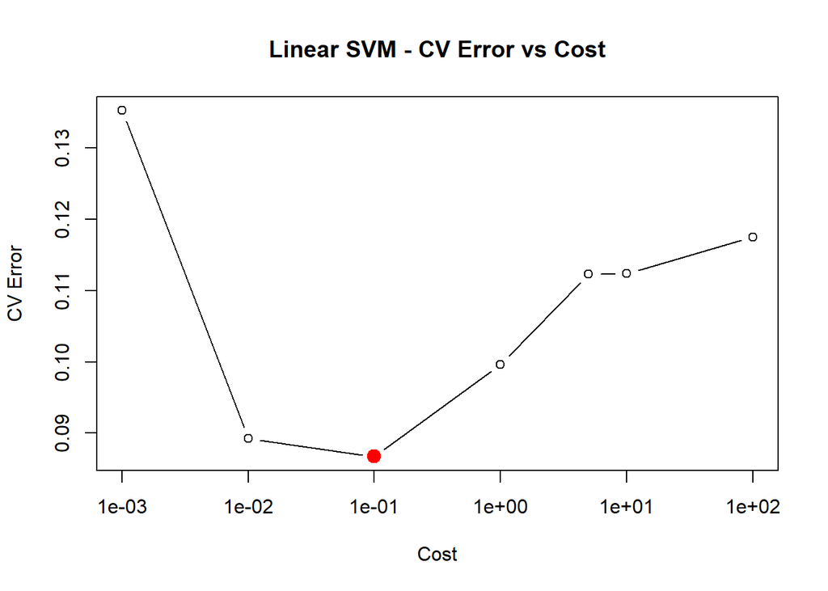

```r
library("ggplot2")
library("reshape2")

# Plot cross-validation errors for linear kernel
plot(tune.linear$performances$cost, tune.linear$performances$error,
     type = "b", log = "x", xlab = "Cost", ylab = "CV Error",
     main = "Linear SVM - CV Error vs Cost")
points(tune.linear$best.parameters$cost,
       tune.linear$performances[tune.linear$performances$cost == tune.linear$best.parameters$cost, "error"],
       col = "red", pch = 19, cex = 1.5)
```

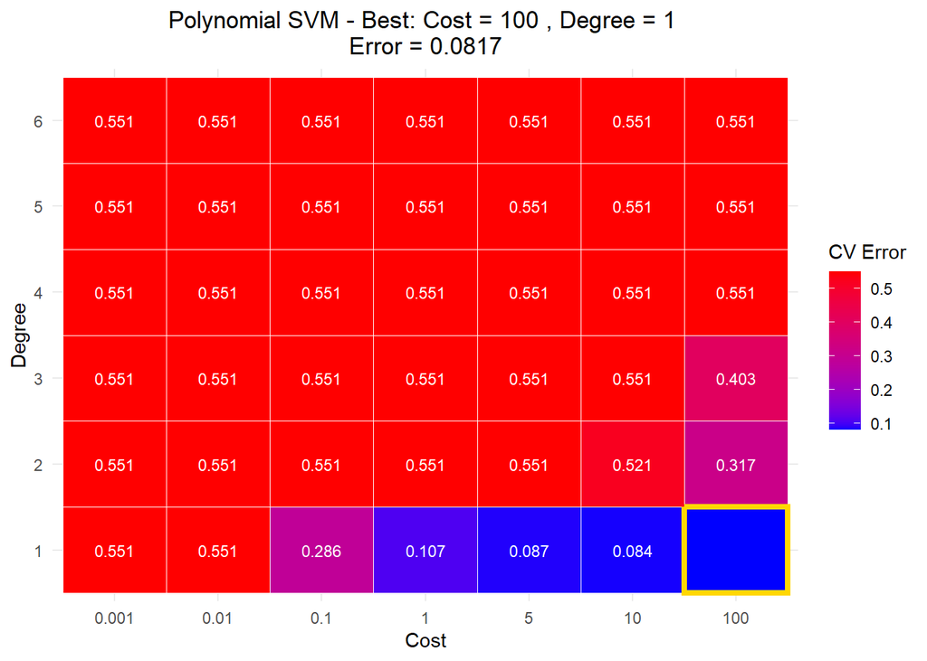

```r
# Heatmaps with best parameters highlighted

# Polynomial SVM heatmap with best parameter highlighted
polynomial_perf <- tune.polynomial$performances
best_poly_cost <- tune.polynomial$best.parameters$cost
best_poly_degree <- tune.polynomial$best.parameters$degree

polynomial_heatmap <- ggplot(polynomial_perf, aes(x = factor(cost), y = factor(degree), fill = error)) +
  geom_tile(color = "white") +
  scale_fill_gradient(low = "blue", high = "red", name = "CV Error") +
  geom_text(aes(label = round(error, 3)), color = "white", size = 3) +
  # Highlight the best parameters
  geom_tile(data = polynomial_perf[polynomial_perf$cost == best_poly_cost &
                                   polynomial_perf$degree == best_poly_degree, ],
            color = "gold", size = 1.5) +
  labs(title = paste("Polynomial SVM - Best: Cost =", best_poly_cost,
                     ", Degree =", best_poly_degree, "\nError =",
                     round(min(polynomial_perf$error), 4)),
       x = "Cost",
       y = "Degree") +
  theme_minimal() +
  theme(plot.title = element_text(hjust = 0.5))

print(polynomial_heatmap)
```

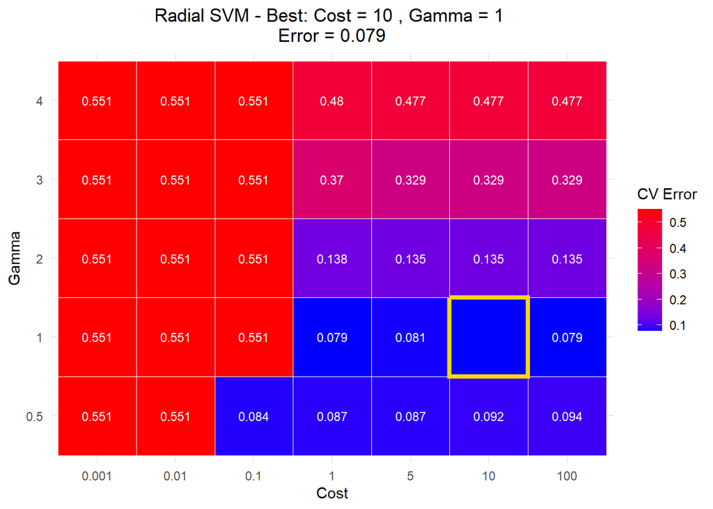

```r
# Radial SVM heatmap with best parameter highlighted
radial_perf <- tune.radial$performances
best_radial_cost <- tune.radial$best.parameters$cost
best_radial_gamma <- tune.radial$best.parameters$gamma

radial_heatmap <- ggplot(radial_perf, aes(x = factor(cost), y = factor(gamma), fill = error)) +
  geom_tile(color = "white") +
  scale_fill_gradient(low = "blue", high = "red", name = "CV Error") +
  geom_text(aes(label = round(error, 3)), color = "white", size = 3) +
  # Highlight the best parameters
  geom_tile(data = radial_perf[radial_perf$cost == best_radial_cost &
                               radial_perf$gamma == best_radial_gamma, ],
            color = "gold", size = 1.5) +
  labs(title = paste("Radial SVM - Best: Cost =", best_radial_cost,
                     ", Gamma =", best_radial_gamma, "\nError =",
                     round(min(radial_perf$error), 4)),
       x = "Cost",
       y = "Gamma") +
  theme_minimal() +
  theme(plot.title = element_text(hjust = 0.5))

print(radial_heatmap)
```

# Chapter 12 Problem 10

a)

```r
set.seed(1)              # for reproducibility

X <- matrix(rnorm(20*3*50), nrow = 60, ncol = 50) # 60x50 Matrix with random values from standard normal distribution.
X[1:20, ] <- X[1:20,] + 2   # class 1 centered around mean 2
X[21:40, ] <- X[21:40,] -2   # class 2 centered around mean -2
# class 3 left with mean 0
```

b)

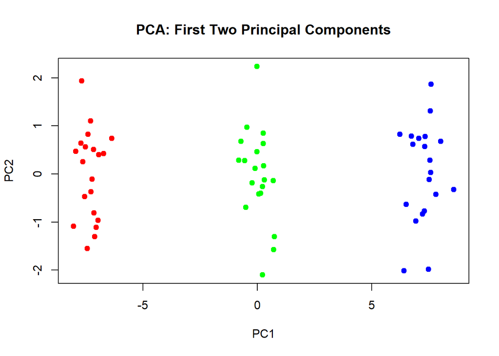

```r
# Performs PCA with scaling
pr.out <- prcomp(X, scale. = TRUE)

# Colors for each class
cls <- rep(c("red", "blue", "green"), each = 20)

# Plot first two principal components colored by true class
plot(pr.out$x[,1], pr.out$x[,2], col = cls, pch = 19,
     xlab = "PC1", ylab = "PC2",
     main = "PCA: First Two Principal Components")
```

c)

```r
set.seed(1)
km.out <- kmeans(X, 3, nstart = 20)
table(Predicted = km.out$cluster, True = rep(1:3, each = 20))
```

```
##          True
## Predicted  1  2  3
##         1  0  0 20
##         2 20  0  0
##         3  0 20  0
```

From the table we can see that the clustering correctly groups observations even though the cluster labels are not aligned with the class labels.

```r
library("StratigrapheR")
# Shift cluster labels to align with class labels
km.out$cluster <- shift(km.out$cluster, n=20)
table(Predicted=km.out$cluster, True= rep(1:3, each=20))
```

```
##          True
## Predicted  1  2  3
##         1 20  0  0
##         2  0 20  0
##         3  0  0 20
```

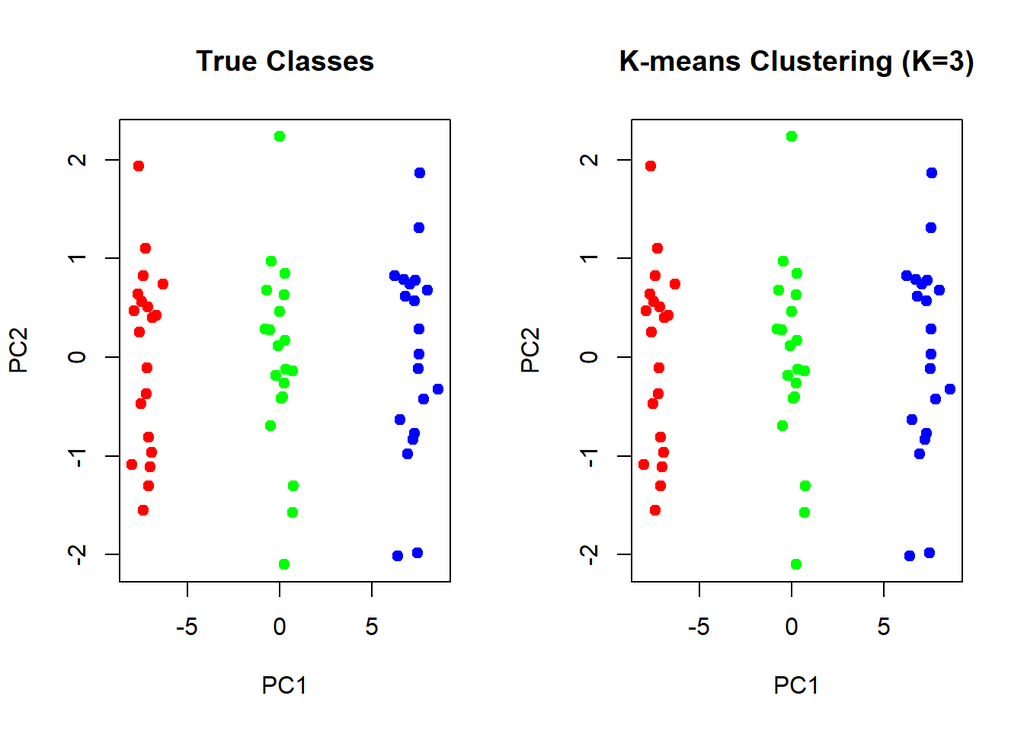

```r
# True class vector and color function
class_vec <- rep(1:3, each = 20)
Cols <- function(x) c("red", "blue", "green")[x]

# Side-by-side plots for comparison
par(mfrow = c(1, 2))

# Left plot: True classes colored by actual labels
plot(pr.out$x[, 1:2],
     col = Cols(class_vec),
     pch = 19,
     xlab = "PC1", ylab = "PC2",
     main = "True Classes")

# Right plot: K-means clustering results colored by cluster assignment
plot(pr.out$x[, 1:2],
     col = Cols(km.out$cluster),
     pch = 19,
     xlab = "PC1", ylab = "PC2",
     main = "K-means Clustering (K=3)")
```

d)

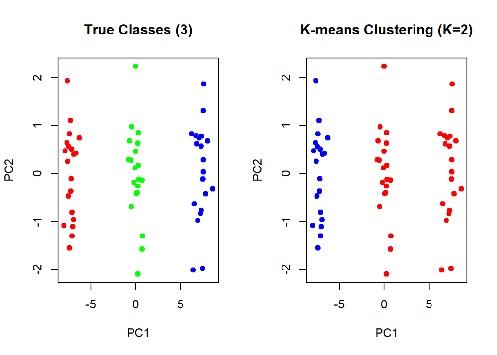

```r
# Perform K-means clustering with K=2 (fewer than true classes)
set.seed(1)
km.out <- kmeans(X, 2, nstart = 20)

# Side-by-side plots
par(mfrow = c(1, 2))

# Left plot: True classes (3 classes)
plot(pr.out$x[, 1:2],
     col = Cols(class_vec),
     pch = 19,
     xlab = "PC1", ylab = "PC2",
     main = "True Classes (3)")

# Right plot: K-means with K=2 (clusters forced into 2 groups)
plot(pr.out$x[, 1:2],
     col = Cols(km.out$cluster),
     pch = 19,
     xlab = "PC1", ylab = "PC2",
     main = "K-means Clustering (K=2)")
```

Here we can see that the K-means clustering grouped observations in the first class as one cluster and the last two classes as the second cluster.

e)

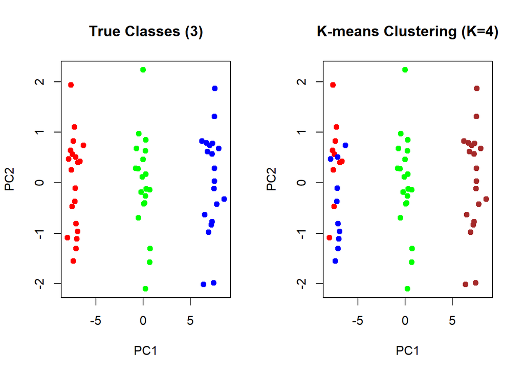

```r
set.seed(1)
km.out <- kmeans(X, 4, nstart = 20)
Cols2 <- function(x)c("red", "blue", "green","brown")[x] # One color for each cluster label

# Side-by-side plots
par(mfrow = c(1, 2))

# Left plot: True classes (3 classes)
plot(pr.out$x[, 1:2],
     col = Cols(class_vec),
     pch = 19,
     xlab = "PC1", ylab = "PC2",
     main = "True Classes (3)")

# Right plot: K-means with K=4
plot(pr.out$x[, 1:2],
     col = Cols2(km.out$cluster),
     pch = 19,
     xlab = "PC1", ylab = "PC2",
     main = "K-means Clustering (K=4)")
```

Here we can see that the second and third classes were correctly grouped into own clusters and the first class was split between the remaining two clusters.